# DataProcessing

**IMPORTS**

```python
import pandas as pd
import sqlite3
import scipy.stats as stats
from statsmodels.stats.weightstats import ztest as ztest
import numpy as np
import matplotlib.pyplot as plt
import seaborn as sns
import datetime
```

### *DATA PROCESSING*

```python
# First, we connect our database sqlite file.
conn = sqlite3.connect("/content/database.sqlite")
crsr = conn.cursor()

# Then, we query to find out what tables we have in our dataset.
query = "SELECT * FROM sqlite_master WHERE type = 'table'"
tables = pd.read_sql(query, conn)
tables
```

|  | type | name | tbl_name | rootpage | sql |
| --- | --- | --- | --- | --- | --- |
| 0 | table | sqlite_sequence | sqlite_sequence | 4 | CREATE TABLE sqlite_sequence(name,seq) |
| 1 | table | Player_Attributes | Player_Attributes | 11 | CREATE TABLE "Player_Attributes" (\n\t`id`\tIN... |
| 2 | table | Player | Player | 14 | CREATE TABLE `Player` (\n\t`id`\tINTEGER PRIMA... |
| 3 | table | Match | Match | 18 | CREATE TABLE `Match` (\n\t`id`\tINTEGER PRIMAR... |
| 4 | table | League | League | 24 | CREATE TABLE `League` (\n\t`id`\tINTEGER PRIMA... |
| 5 | table | Country | Country | 26 | CREATE TABLE `Country` (\n\t`id`\tINTEGER PRIM... |
| 6 | table | Team | Team | 29 | CREATE TABLE "Team" (\n\t`id`\tINTEGER PRIMARY... |
| 7 | table | Team_Attributes | Team_Attributes | 2 | CREATE TABLE `Team_Attributes` (\n\t`id`\tINTE... |

As we see above, we have 7 different SQL tables in our dataset. The one's relevant to us are the 'Player', and 'Player Attributes' table.

Let's now explore these two in detail.

```python
player_query = "SELECT * FROM Player"
player_data = pd.read_sql(player_query, conn)
player_data.head()
```

|  | id | player_api_id | player_name | player_fifa_api_id | birthday | height | weight |
| --- | --- | --- | --- | --- | --- | --- | --- |
| 0 | 1 | 505942 | Aaron Appindangoye | 218353 | 1992-02-29 00:00:00 | 182.88 | 187 |
| 1 | 2 | 155782 | Aaron Cresswell | 189615 | 1989-12-15 00:00:00 | 170.18 | 146 |
| 2 | 3 | 162549 | Aaron Doran | 186170 | 1991-05-13 00:00:00 | 170.18 | 163 |
| 3 | 4 | 30572 | Aaron Galindo | 140161 | 1982-05-08 00:00:00 | 182.88 | 198 |
| 4 | 5 | 23780 | Aaron Hughes | 17725 | 1979-11-08 00:00:00 | 182.88 | 154 |

> The Player data contains information about each of the players in the database. Each player has their name, unique id, birthday and physical real-world attribiutes like height and weight in the table.

```python
player_attributes_query = "SELECT * FROM Player_Attributes"
player_attributes_data = pd.read_sql(player_attributes_query, conn)

# creating a column for athleticism which is based on the attributes - acceleration, sprint_speeed, agility, reactions, balance, jumping, stamina, strength
player_attributes_data['athleticism'] = player_attributes_data[['acceleration', 'sprint_speed', 'agility', 'reactions', 'balance', 'jumping', 'stamina', 'strength']].mean(axis=1)
player_attributes_data['general_performance_score'] = player_attributes_data[['crossing', 'finishing', 'heading_accuracy', 'short_passing', 'volleys', 'dribbling', 'curve', 'free_kick_accuracy', 'long_passing', 'ball_control', 'acceleration', 'sprint_speed', 'agility', 'reactions', 'balance', 'shot_power', 'jumping', 'stamina', 'strength', 'long_shots', 'aggression', 'interceptions', 'positioning', 'vision', 'penalties', 'marking', 'standing_tackle', 'sliding_tackle', 'curve']].mean(axis=1)
player_attributes_data['gk_performance_score'] = player_attributes_data[['short_passing', 'long_passing', 'agility', 'reactions', 'jumping', 'aggression', 'gk_diving', 'gk_handling', 'gk_kicking', 'gk_positioning', 'gk_reflexes']].mean(axis=1)
player_attributes_data.head()
```

|  | id | player_fifa_api_id | player_api_id | date | overall_rating | potential | preferred_foot | attacking_work_rate | defensive_work_rate | crossing | ... | standing_tackle | sliding_tackle | gk_diving | gk_handling | gk_kicking | gk_positioning | gk_reflexes | athleticism | general_performance_score | gk_performance_score |
| --- | --- | --- | --- | --- | --- | --- | --- | --- | --- | --- | --- | --- | --- | --- | --- | --- | --- | --- | --- | --- | --- |
| 0 | 1 | 218353 | 505942 | 2016-02-18 00:00:00 | 67.0 | 71.0 | right | medium | medium | 49.0 | ... | 69.0 | 69.0 | 6.0 | 11.0 | 10.0 | 8.0 | 8.0 | 60.375 | 56.068966 | 36.636364 |
| 1 | 2 | 218353 | 505942 | 2015-11-19 00:00:00 | 67.0 | 71.0 | right | medium | medium | 49.0 | ... | 69.0 | 69.0 | 6.0 | 11.0 | 10.0 | 8.0 | 8.0 | 60.375 | 56.068966 | 36.636364 |
| 2 | 3 | 218353 | 505942 | 2015-09-21 00:00:00 | 62.0 | 66.0 | right | medium | medium | 49.0 | ... | 66.0 | 69.0 | 6.0 | 11.0 | 10.0 | 8.0 | 8.0 | 60.375 | 54.689655 | 35.909091 |
| 3 | 4 | 218353 | 505942 | 2015-03-20 00:00:00 | 61.0 | 65.0 | right | medium | medium | 48.0 | ... | 63.0 | 66.0 | 5.0 | 10.0 | 9.0 | 7.0 | 7.0 | 60.250 | 53.724138 | 35.090909 |
| 4 | 5 | 218353 | 505942 | 2007-02-22 00:00:00 | 61.0 | 65.0 | right | medium | medium | 48.0 | ... | 63.0 | 66.0 | 5.0 | 10.0 | 9.0 | 7.0 | 7.0 | 60.250 | 53.724138 | 35.090909 |

5 rows × 45 columns

> The Player Attributes data contains specific information about each of the players in the database. Each player has a rating for every attribute, where a higher relative rating indicates better performance.

> We will use these attributes in our analysis for player position prediction.

> For a cleaner dataser, we join the two datasets above using the merge function from the pandas library.

> We then start with basic data cleaning and processing in the merged dataset by dropping irrelevant columns, dropping duplicated entries for the same players and calculating the age instead of the birthday column.

```python
# We merge the two tables
merged_player_data = pd.merge(player_data, player_attributes_data, on='player_api_id')

# We drop the irrelevant columns.
merged_player_data.drop(columns=['player_fifa_api_id_x', 'id_y', 'id_x', 'player_fifa_api_id_y'], inplace=True)

# We drop duplicate entries in the merged dataset.
merged_player_data = merged_player_data.drop_duplicates(subset='player_name', keep='first')

# We use the birthday column to calculate the age of each of the players.
def calculate_age(birthday):
    date_str, _ = birthday.split(" ")
    birthdate = datetime.datetime.strptime(date_str, '%Y-%m-%d').date()
    today = datetime.date.today()
    age = today.year - birthdate.year - ((today.month, today.day) < (birthdate.month, birthdate.day))
    return age

# We create a new column to represent the Age of the player.
merged_player_data['age'] = merged_player_data['birthday'].apply(calculate_age)

# creating a column title "physical" which is based on the attributes - age, height, and weight
merged_player_data['physical'] = merged_player_data[['height', 'weight', 'age']].mean(axis=1)

# We then drop the birthday column as it is unnecessary now.
merged_player_data.drop(columns=['birthday', 'date'], inplace=True)

merged_player_data
```

|  | player_api_id | player_name | height | weight | overall_rating | potential | preferred_foot | attacking_work_rate | defensive_work_rate | crossing | ... | gk_diving | gk_handling | gk_kicking | gk_positioning | gk_reflexes | athleticism | general_performance_score | gk_performance_score | age | physical |
| --- | --- | --- | --- | --- | --- | --- | --- | --- | --- | --- | --- | --- | --- | --- | --- | --- | --- | --- | --- | --- | --- |
| 0 | 505942 | Aaron Appindangoye | 182.88 | 187 | 67.0 | 71.0 | right | medium | medium | 49.0 | ... | 6.0 | 11.0 | 10.0 | 8.0 | 8.0 | 60.375 | 56.068966 | 36.636364 | 32 | 133.960000 |
| 5 | 155782 | Aaron Cresswell | 170.18 | 146 | 74.0 | 76.0 | left | high | medium | 80.0 | ... | 14.0 | 7.0 | 9.0 | 9.0 | 12.0 | 76.500 | 69.551724 | 44.363636 | 34 | 116.726667 |
| 38 | 162549 | Aaron Doran | 170.18 | 163 | 65.0 | 67.0 | right | medium | medium | 64.0 | ... | 16.0 | 11.0 | 12.0 | 9.0 | 13.0 | 72.625 | 60.965517 | 40.909091 | 32 | 121.726667 |
| 64 | 30572 | Aaron Galindo | 182.88 | 198 | 69.0 | 69.0 | right | medium | medium | 57.0 | ... | 15.0 | 12.0 | 13.0 | 12.0 | 11.0 | 54.625 | 53.068966 | 40.818182 | 41 | 140.626667 |
| 87 | 23780 | Aaron Hughes | 182.88 | 154 | 70.0 | 70.0 | right | medium | medium | 46.0 | ... | 8.0 | 6.0 | 16.0 | 12.0 | 11.0 | 53.375 | 51.448276 | 38.000000 | 44 | 126.960000 |
| ... | ... | ... | ... | ... | ... | ... | ... | ... | ... | ... | ... | ... | ... | ... | ... | ... | ... | ... | ... | ... | ... |
| 183924 | 26357 | Zoumana Camara | 182.88 | 168 | 73.0 | 73.0 | right | low | medium | 42.0 | ... | 14.0 | 10.0 | 11.0 | 8.0 | 12.0 | 65.250 | 56.655172 | 42.454545 | 45 | 131.960000 |
| 183937 | 111182 | Zsolt Laczko | 182.88 | 176 | 63.0 | 67.0 | left | high | medium | 65.0 | ... | 9.0 | 8.0 | 5.0 | 5.0 | 8.0 | 67.000 | 59.103448 | 38.454545 | 37 | 131.960000 |
| 183953 | 36491 | Zsolt Low | 180.34 | 154 | 68.0 | 73.0 | left | None | _0 | 64.0 | ... | 15.0 | 13.0 | 5.0 | 6.0 | 6.0 | 65.500 | 62.482759 | 38.090909 | 45 | 126.446667 |
| 183960 | 35506 | Zurab Khizanishvili | 185.42 | 172 | 67.0 | 78.0 | right | None | _0 | 48.0 | ... | 14.0 | 7.0 | 15.0 | 10.0 | 12.0 | 63.250 | 55.275862 | 38.636364 | 42 | 133.140000 |
| 183968 | 39902 | Zvjezdan Misimovic | 180.34 | 176 | 78.0 | 78.0 | right | medium | low | 77.0 | ... | 9.0 | 13.0 | 8.0 | 15.0 | 5.0 | 64.125 | 66.068966 | 42.818182 | 41 | 132.446667 |

10848 rows × 47 columns

```python
merged_player_data = merged_player_data.dropna()
merged_player_data.shape
```

```
(10213, 47)
```

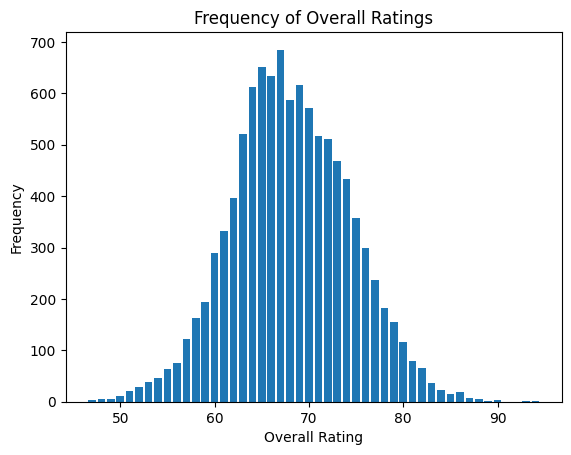

```python
# prompt: create a plot showing the frequency of overall ratings

import matplotlib.pyplot as plt

# Create a bar chart of the frequency of overall ratings
plt.bar(merged_player_data['overall_rating'].value_counts().index, merged_player_data['overall_rating'].value_counts().values)
plt.xlabel('Overall Rating')
plt.ylabel('Frequency')
plt.title('Frequency of Overall Ratings')
plt.show()
```